# Capítulo 4 - Meta Modelo

### Modelo NR__São_Paulo

[figure not shown]

### Resumo do modelo

- Selecionamos os 3 melhores modelos e árvore do comparativo do capítulo 3
- Selecionaremos 3 modelos lineares com o uso AutoML
- Validaremos os 6 modelos com Group k-fold e Time Series k-fold
- Otimização hiperparâmetros via busca aleatória e busca bayesiana
- A métrica escolhida foi a correlação de spearman por era (Validation_Mean)

#### Meta modelo

- Criaremos 5 modelos de segundo nível com as predições dos 15 modelos anteriores
- Faremos uma comparação de resultados
- Discutiremos possíveis erros e melhorias

### Seleção de modelos lineares com AutoML

Otimizando para o MSE

```python
load_table = pd.read_excel("../../reports/pycaret_compare_results.xlsx", index=True)
load_table
```

|  | Model | MAE | MSE | RMSE | R2 | RMSLE | MAPE | TT (Sec) |
| --- | --- | --- | --- | --- | --- | --- | --- | --- |
| 0 | Orthogonal Matching Pursuit | 0.3012 | 0.1244 | 0.3527 | 0.0015 | 0.2461 | 0.4623 | 1.3055 |
| 1 | Bayesian Ridge | 0.3009 | 0.1244 | 0.3527 | 0.0019 | 0.2461 | 0.4616 | 37.0157 |
| 2 | Ridge Regression | 0.3017 | 0.1245 | 0.3528 | 0.0013 | 0.2461 | 0.4637 | 6.7043 |
| 3 | Linear Regression | 0.3017 | 0.1245 | 0.3528 | 0.0013 | 0.2461 | 0.4637 | 6.2805 |
| 4 | Automatic Relevance Determination | 0.3008 | 0.1245 | 0.3529 | 0.0009 | 0.2462 | 0.4607 | 14.4360 |
| 5 | Lasso Regression | 0.2991 | 0.1246 | 0.3530 | 0.0000 | 0.2463 | 0.4565 | 2.7285 |
| 6 | Elastic Net | 0.2991 | 0.1246 | 0.3530 | 0.0000 | 0.2463 | 0.4565 | 2.0007 |
| 7 | Least Angle Regression | 0.3022 | 0.1246 | 0.3530 | -0.0002 | 0.2463 | 0.4649 | 1.4324 |
| 8 | Lasso Least Angle Regression | 0.2991 | 0.1246 | 0.3530 | 0.0000 | 0.2463 | 0.4565 | 1.4809 |

```python
print("Obs: Optamos pelo ridge, ao invés do bayesian ridge devido ao tempo comp.")
```

```
Obs: Optamos pelo ridge, ao invés do bayesian ridge devido ao tempo comp.
```

```python
print("Obs: Modelos de regressão robusta, e outros como SVM e KNN (não linear),\nnão convergiram ou tiveram péssimo resultado")
```

```
Obs: Modelos de regressão robusta, e outros como SVM e KNN (não linear),
não convergiram ou tiveram péssimo resultado
```

### Modelos lineares

#### Regressão Linear (OLS)

$$\min_{w} || X w - y||_2^2$$

#### Ridge

$$\min_{w} || X w - y||_2^2 + \alpha ||w||_2^2$$

#### OMP

$$\underset{w}{\operatorname{arg\,min\,}} ||y - Xw||_2^2 \text{ subject to } ||w||_0 \leq n_{\text{nonzero_coefs}}$$

### Validação Group 3-Fold

[figure not shown]

*Fonte: https://scikit-learn.org/stable/modules/cross_validation.html*

#### Otimização de Hiperparâmetros

[figure not shown]

*Fonte: BERGSTRA, J., BENGIO, Y. “Random search for hyper-parameter optimization”, Journal of Machine Learning Research, v. 13, pp. 281–305, 2012*

### Treinando os modelos

#### Regressão Linear

$$\min_{w} || X w - y||_2^2$$

```python
from sklearn.linear_model import LinearRegression

lr_param_grid =  {
    'fit_intercept' : [True, False],
    'normalize' : [True, False],

}


result = evaluation.evaluate_model(df_training[features],
                                   df_training[target],
                                   LinearRegression(),
                                   'lr',
                                   lr_param_grid,
                                   scorer,
                                   n_iter=4,
                                   cv_folds=cv_grp,
                                   pipeline=None)

results.append(result)
```

```
==> Starting K-fold cross validation for lr model, 501808 examples
Fitting 3 folds for each of 4 candidates, totalling 12 fits
```

```
[Parallel(n_jobs=-1)]: Using backend LokyBackend with 4 concurrent workers.
[Parallel(n_jobs=-1)]: Done   8 out of  12 | elapsed:  8.5min remaining:  4.2min
[Parallel(n_jobs=-1)]: Done  12 out of  12 | elapsed: 16.3min finished
```

```
==> Elapsed seconds: 1034.874
Best lr model: LinearRegression()
Best lr score (val): 0.0354
```

```python
print("LinearRegression(fit_intercept=True, normalize=False)")
```

```
LinearRegression(fit_intercept=True, normalize=False)
```

#### Ridge

$$\min_{w} || X w - y||_2^2 + \alpha ||w||_2^2$$

```python
from sklearn.linear_model import Ridge

ridge_param_grid =  {
    'fit_intercept' : [True, False],
    'normalize' : [True, False],
    'alpha' : Real(10**-1, 10**1, "log-uniform")

}


result = evaluation.evaluate_model(df_training[features],
                                   df_training[target],
                                   Ridge(),
                                   'ridge',
                                   ridge_param_grid,
                                   scorer,
                                   n_iter=20,
                                   cv_folds=cv_grp,
                                   pipeline=None)

results.append(result)
```

[output not shown]

#### OMP

$$\underset{w}{\operatorname{arg\,min\,}} ||y - Xw||_2^2 \text{ subject to } ||w||_0 \leq n_{\text{nonzero_coefs}}$$

```python
from sklearn.linear_model import OrthogonalMatchingPursuit

omp_param_grid =  {
    'fit_intercept' : [True, False],
    'normalize' : [True, False],
    'n_nonzero_coefs' : Integer(1, len(features), 'uniform')

}


result = evaluation.evaluate_model(df_training[features],
                                   df_training[target],
                                   OrthogonalMatchingPursuit(),
                                   'omp',
                                   omp_param_grid,
                                   scorer,
                                   n_iter=30,
                                   cv_folds=cv_grp,
                                   pipeline=None)

results.append(result)
```

[output not shown]

### Todos os modelos são treinados dessa forma

### Modelos de Árvore (Não Lineares)

- Cart
- bagging (random forest)
- boosting (Adaboost e GBM)

[figure not shown]

#### Xgboost Regressor

[figure not shown]

#### Treinando o modelo

```python
from xgboost import XGBRegressor
#example scripts
#XGBRegressor(max_depth=5, learning_rate=0.01, n_estimators=2000, n_jobs=-1, colsample_bytree=0.1)

xgb_param_grid = {
        #step 1 & 6
        'n_estimators' : Integer(500, 3000, 'uniform'),
        'learning_rate' : Real(10**-3, 10**-1, "log-uniform"),

        #step 2
        'max_depth' : Integer(3, 10, 'uniform'),
        'min_child_weight': Integer(1, 10, 'uniform'),

        #step 3
        'gamma' :Real(1e-5, 6, 'log-uniform'),


        #step 4
        'subsample' : Real(5e-2, 1, 'uniform'),
        'colsample_bytree':Real(5e-2, 1, 'uniform'),

        #step 5
        'reg_alpha' : Real(1, 100, 'log-uniform'),

        #utils
        'objective': ["reg:squarederror"],
        'early_stopping_rounds' : [30],
        'tree_method' : ['gpu_hist'],
        'gpu_id' : [0]


}


result = evaluation.evaluate_model_skopt(df_training[features],
                                         df_training[target],
                                         XGBRegressor(),
                                         'xgb',
                                         xgb_param_grid,
                                         scorer,
                                         n_jobs=-1,
                                         n_iter=50,
                                         cv_folds=cv_grp,
                                         pipeline=None)

results.append(result)
```

[output not shown]

#### LightGBM Regressor

[figure not shown]

#### Treinando o modelo

```python
from lightgbm import LGBMRegressor

lgbm_param_grid = {


    #step 1 & 6
    'n_estimators' : Integer(400, 3000, 'uniform'),
    'learning_rate' : , Real(10**-3, 10**-1, "log-uniform"),


    #step 2
    'num_leaves': Integer(50, 250, "uniform"),
    'min_data_in_leaf' : Integer(100, 2000, 'uniform'),
    'max_depth' : Integer(3, 30, 'uniform'),


    #step 3
    'bagging_fraction' : Real(1e-1, 1, 'uniform'),
    'bagging_temperature': Real(1e-1, 1.0, 'unifom'),

    #step 4
    'colsample_bytree':Real(1e-1, 1, 'uniform'),
    'subsample':  Real(1e-1, 1, 'uniform'),

    #step 5
    'reg_lambda': Real(10**-2, 1, "log-uniform"),


    #utils
    'boosting_type': ['goss'],
    'device_type' : ['gpu']

}


result = evaluation.evaluate_model_skopt(df_training[features],
                                         df_training[target],
                                         LGBMRegressor(),
                                         'lgbm',
                                         lgbm_param_grid,
                                         scorer,
                                         n_iter=20,
                                         cv_folds=cv_grp,
                                         pipeline=None)

results.append(result)
```

[output not shown]

#### XGB Ranker

[figure not shown]

#### Treinando o modelo

```python
from xgboost import XGBRanker


xgb_param_grid = {
        #step 1 & 6
        'n_estimators' : Integer(500, 3000, 'uniform'),
        'learning_rate': Real(10**-3, 10**-1, "log-uniform"),


        #step 2
        'max_depth' : Integer(3, 10, 'uniform'),
        'min_child_weight': Integer(8, 16, 'uniform'),

        #step 3
        'gamma' : Real(1e-5, 6, 'log-uniform'),


        #step 4
        'subsample' :  Real(1e-1, 1, 'uniform'),
        'colsample_bytree':  Real(1e-1, .5, 'uniform'),

        #step 5
        'reg_alpha' :  Real(1, 100, 'log-uniform'),


        #utils
        'objective': ["rank:pairwise"],
        'early_stopping_rounds' : [30],
        'tree_method' : ['gpu_hist'],
        'gpu_id' : [0],


}


class MyXGBRanker(XGBRanker):
    def fit(self, x, y):
        cdf = x.groupby('era').agg(['count'])
        group = cdf[cdf.columns[0]].values
        return super().fit(x[features], y, group=group)

    def predict(self, x):
        return super().predict(x[features])


result = evaluation.evaluate_model_skopt(df_training[['era']+features], df_training[target],
                                          MyXGBRanker(), 'xgb_ranker',
                                          xgb_param_grid,
                                          scorer,
                                          n_jobs=-1,
                                          n_iter=10,
                                          cv_folds=cv_grp,
                                          pipeline=None)

results.append(result)
```

[output not shown]

### Avaliando as predições nas eras 1-120 (validação cruzada)

```python
%%time

from joblib import dump, load
file_path = '../../models/sao_paulo/'

models, res_cv, preds = dict(), dict(), dict()
era_scores, df_metrics, feat_corrs = dict(), dict(), dict()
model_names = ['ex_preds', 'lr', 'ridge', 'omp', 'xgb',  'lgbm', 'xgb_ranker']

#model_names = ['ex_preds', 'xgb_ranker', 'ridge', 'omp', 'xgb',  'lgbm', 'xgb_ranker']

target = 'target_kazutsugi'
print("target name (kaz): ", target)
for model in model_names[1:]:
    #load model complete pipe
    print("creating predictions to:", model)
    models[model] = load(file_path + model + '-cv.pkl')

    #loading cv scores
    res_cv[model] = evaluation.get_cv_scores(models[model])

    #predicoes val1 & val2
    #preds[model] = models[model].predict(df_validation[features])
    preds[model] = models[model].model.predict(df_validation[features])


    #salvando as metricas
    era_scores[model], df_metrics[model], feat_corrs[model], ex_preds = \
                        metrics.submission_metrics(df_validation, preds[model], model, True)



#add ex_preds
print("creating predictions to: ex_preds")
preds['ex_preds'] = np.array(ex_preds)
era_scores['ex_preds'], df_metrics['ex_preds'], feat_corrs['ex_preds'], ex_preds = \
                        metrics.submission_metrics(df_validation, preds['ex_preds'], "ex_preds", False)



#dict to dataframe
df_res_cv = pd.DataFrame.from_dict(res_cv)
df_preds = pd.DataFrame.from_dict(preds)
df_era_scores = pd.DataFrame.from_dict(era_scores)
df_feat_corrs = pd.DataFrame.from_dict(feat_corrs)
df_metrics_cons = metrics.metrics_consolidated(df_metrics)
```

```
target name (kaz):  target_kazutsugi
creating predictions to: lr
creating predictions to: ridge
creating predictions to: omp
creating predictions to: xgb
creating predictions to: lgbm
creating predictions to: xgb_ranker
creating predictions to: ex_preds
CPU times: user 5min 13s, sys: 41.2 s, total: 5min 54s
Wall time: 8min 12s
```

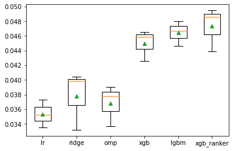

```python
_ = plt.boxplot(res_cv.values(), labels=res_cv.keys(), showmeans=True)
```

### Avaliando o treinamento

```python
#images
from IPython.display import HTML, display
display(HTML("<table><tr><td><img src='https://github.com/nicholasrichers/dissertacao/blob/master/references/figures/cap4/learning_curve_lr.png?raw=true'></td><td><img src='https://github.com/nicholasrichers/dissertacao/blob/master/references/figures/cap4/lerning_curve_xgb.png?raw=true'></td></tr></table>"))
```

[output not shown]

### Observando os retornos por era 121-206

```python
visualize.plot_era_scores(df_era_scores, model_names)
```

[interactive chart not shown]

### Diagnóstico

```python
print("Menor é melhor:", min_cols)

leaderboard = df_metrics_cons[df_metrics_cons.Categoria.isin(["Performance", "Risk", "MMC"])].loc[:,model_names]
leaderboard.astype(float).style.apply(visualize.highlight_max, axis = 1)
```

```
Menor é melhor: ['Feat_exp_max', 'Validation_SD', 'corr_with_example_preds']
```

| Metrica | ex_preds | lr | ridge | omp | xgb | lgbm | xgb_ranker |
| --- | --- | --- | --- | --- | --- | --- | --- |
| Validation_Sharpe | 0.9588 | 0.5411 | 0.4846 | 0.5391 | 0.9584 | 1.1423 | 0.8849 |
| Validation_Mean | 0.0289 | 0.0177 | 0.0172 | 0.0180 | 0.0270 | 0.0299 | 0.0259 |
| Feat_neutral_mean | 0.0260 | 0.0008 | -0.0011 | 0.0053 | 0.0213 | 0.0259 | 0.0211 |
| Validation_SD | 0.0301 | 0.0327 | 0.0354 | 0.0334 | 0.0282 | 0.0262 | 0.0293 |
| Feat_exp_max | 0.2917 | 0.2589 | 0.2690 | 0.2707 | 0.2877 | 0.2526 | 0.3139 |
| Max_Drawdown | -0.0775 | -0.1266 | -0.1320 | -0.1262 | -0.0581 | -0.0511 | -0.0805 |
| corr_plus_mmc_sharpe | 0.9588 | 0.3054 | 0.2246 | 0.3064 | 0.8469 | 1.2072 | 0.7693 |
| val_mmc_mean | 0.0000 | -0.0008 | -0.0037 | -0.0009 | 0.0018 | 0.0055 | -0.0013 |
| corr_with_example_preds | 1.0000 | 0.6403 | 0.7032 | 0.6544 | 0.8831 | 0.8791 | 0.9347 |

### Modelos com validação por série temporal

[figure not shown]

*Fonte: https://scikit-learn.org/stable/modules/cross_validation.html*

### Avaliando as predições nas eras X-120

```python
%%time
from joblib import dump, load
file_path = '../../models/sao_paulo/'

models_ts, preds_ts, feat_corrs_ts = dict(), dict(), dict()
era_scores_ts, df_metrics_ts, res_cv_ts = dict(), dict(), dict()

#models
model_ts = ['lr_ts', 'ridge_ts', 'omp_ts', 'xgb_ts', 'lgbm_ts', 'xgb_ranker_ts']
model_names_ts = ['ex_preds'] + model_ts
#model_names_ts = ['ex_preds', 'omp_ts']#,'xgb_ts']#, 'xgb_ranker_ts']

target = 'target_kazutsugi'
print("target name (kaz): ", target)
for model in model_names_ts[1:]:
    #load model complete pipe
    print("creating predictions to:", model)
    models_ts[model] = load(file_path + model + '-cv.pkl')

    #loading cv scores
    res_cv_ts[model] = evaluation.get_cv_scores(models_ts[model])[0:3]


    #predicoes val1 & val2
    preds_ts[model] = models_ts[model].model.predict(df_validation[features])


    #salvando as metricas
    era_scores_ts[model], df_metrics_ts[model], feat_corrs_ts[model], ex_preds = \
                        metrics.submission_metrics(df_validation, preds_ts[model], model, True)



#add ex_preds
print("creating predictions to: ex_preds")
preds_ts['ex_preds'] = np.array(ex_preds)
era_scores_ts['ex_preds'], df_metrics_ts['ex_preds'], feat_corrs_ts['ex_preds'], ex_preds = \
                        metrics.submission_metrics(df_validation, preds_ts['ex_preds'], "ex_preds", False)




#dict to dataframe
df_res_cv_ts = pd.DataFrame.from_dict(res_cv_ts)
df_preds_ts = pd.DataFrame.from_dict(preds_ts)
df_era_scores_ts = pd.DataFrame.from_dict(era_scores_ts)
df_feat_corrs_ts = pd.DataFrame.from_dict(feat_corrs_ts)
df_metrics_cons_ts = metrics.metrics_consolidated(df_metrics_ts)
```

```
target name (kaz):  target_kazutsugi
creating predictions to: lr_ts
creating predictions to: ridge_ts
creating predictions to: omp_ts
creating predictions to: xgb_ts
creating predictions to: lgbm_ts
creating predictions to: xgb_ranker_ts
creating predictions to: ex_preds
CPU times: user 4min 21s, sys: 31.9 s, total: 4min 52s
Wall time: 5min 32s
```

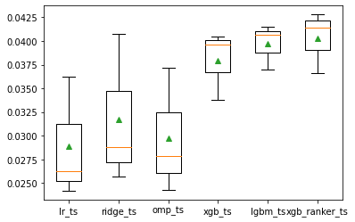

```python
_ = plt.boxplot(res_cv_ts.values(), labels=res_cv_ts.keys(), showmeans=True)
```

### Observando os retornos por era 121-206

```python
visualize.plot_era_scores(df_era_scores_ts, model_names_ts)
```

[interactive chart not shown]

### Diagnóstico

```python
print("Menor é melhor:", min_cols)
leaderboard_ts = df_metrics_cons_ts[df_metrics_cons_ts.Categoria.isin(["Performance", "Risk", "MMC"])].loc[:,model_names_ts]
leaderboard_ts.astype(float).style.apply(visualize.highlight_max, axis = 1)
```

```
Menor é melhor: ['Feat_exp_max', 'Validation_SD', 'corr_with_example_preds']
```

| Metrica | ex_preds | lr_ts | ridge_ts | omp_ts | xgb_ts | lgbm_ts | xgb_ranker_ts |
| --- | --- | --- | --- | --- | --- | --- | --- |
| Validation_Sharpe | 0.9588 | 0.5411 | 0.4649 | 0.5075 | 1.0440 | 0.9155 | 0.9355 |
| Validation_Mean | 0.0289 | 0.0177 | 0.0170 | 0.0173 | 0.0275 | 0.0264 | 0.0267 |
| Feat_neutral_mean | 0.0260 | 0.0008 | 0.0006 | 0.0041 | 0.0229 | 0.0215 | 0.0224 |
| Validation_SD | 0.0301 | 0.0327 | 0.0366 | 0.0341 | 0.0263 | 0.0288 | 0.0286 |
| Feat_exp_max | 0.2917 | 0.2589 | 0.2995 | 0.2694 | 0.2529 | 0.2709 | 0.3101 |
| Max_Drawdown | -0.0775 | -0.1266 | -0.1304 | -0.1295 | -0.0576 | -0.0732 | -0.0722 |
| corr_plus_mmc_sharpe | 0.9588 | 0.3054 | 0.2122 | 0.2632 | 1.0310 | 0.8102 | 0.8699 |
| val_mmc_mean | 0.0000 | -0.0008 | -0.0036 | -0.0019 | 0.0024 | -0.0002 | -0.0005 |
| corr_with_example_preds | 1.0000 | 0.6403 | 0.6954 | 0.6597 | 0.8849 | 0.9171 | 0.9391 |

### Otimização Bayesiana

[figure not shown]

#### Função Substituta (surrogate function)

Em termos probabilísticos, a função substituta é a probabilidade condicional $P(f|D)$ da função objetivo $(f)$, dado as amostras $(D)$ ou mais formalmente:

$$P(f|D) = P(D|f) P(f)$$$$Posterior = Likelihood * Prior$$

#### Frazier (2018), recomenda configurar o problema como uma regressão, usando Processo Gaussiano ou Random Forest

- Um Processo Gaussiano é um modelo que constrói uma distribuição de probabilidade conjunta sobre as variáveis, assumindo uma distribuição gaussiana multivariada.

#### Função de aquisição

- A função de aquisição $(P(D|f))$ é responsável por indicar o próximo candidato a ser avaliado pela função objetivo a partir do candidato de maior de melhoria esperada.

$$EI_n(x):= E_n[[f(x)-f^{*}_n]^{+}]$$

- A expressão fechada para o cálculo de $EI_n(x)$ pode ser encontrada em Frazier (2018) e obtidas usando métodos quasi-Newton como L-BFGS.

[figure not shown]

*Fonte: FRAZIER, P. I. “A Tutorial on Bayesian Optimization”. 2018.*

### Treinando modelos com busca bayesiana

- O objetivo é performar uma busca de hiperparâmetros mais agressiva
- Otimizaremos todos os hiperparâmetros de uma vez (+200 iterações)
- Faremos apenas nos 3 modelos de árvore
- Random Forest foi mais veloz que o processo gaussiano (sem perda de performance)
- Não faremos validação cruzada para diminuir o tempo computacional
- Testaremos o modelos nas eras (1,4,7,10,13...), treinaremos nas restantes

### Avaliando as predições nas eras 1-120 [::3]

```python
%%time
from joblib import dump, load
file_path = '../../models/sao_paulo/'

cv_values = dict()
cv_values['xgb_forest'] = [0.0402, 0.0402, 0.0402]
cv_values["lgbm_forest"] = [0.0401, 0.0401, 0.0401]
cv_values["xgb_ranker_forest"]  = [0.0391, 0.0391, 0.0391]

models_forest, preds_forest, feat_corrs_forest = dict(), dict(), dict()
era_scores_forest, df_metrics_forest, res_cv_forest = dict(), dict(), dict()

model_cv = ['xgb', 'lgbm', 'xgb_ranker']
model_ts = ['xgb_ts', 'lgbm_ts', 'xgb_ranker_ts']
model_forest = ['xgb_forest', "lgbm_forest", "xgb_ranker_forest"]


model_names_forest = ['ex_preds'] + model_cv + model_ts + model_forest
#model_names_forest = ['ex_preds', 'xgb_ts']#,'xgb_forest']#, 'xgb_ranker_forest']

target = 'target_kazutsugi'
print("target name (kaz): ", target)
for model in model_names_forest[1:]:
    #load model complete pipe
    print("creating predictions to:", model)
    models_forest[model] = load(file_path + model + '-cv.pkl')

    if model in model_forest:
        res_cv_forest[model] = cv_values[model]
    else:
        res_cv_forest[model] = evaluation.get_cv_scores(models_forest[model])

    #predicoes val1 & val2
    preds_forest[model] = models_forest[model].model.predict(df_validation[features])


    #salvando as metricas
    era_scores_forest[model], df_metrics_forest[model], feat_corrs_forest[model], ex_preds = \
                        metrics.submission_metrics(df_validation, preds_forest[model], model, True)



#add ex_preds
print("creating predictions to: ex_preds")
preds_forest['ex_preds'] = np.array(ex_preds)
era_scores_forest['ex_preds'], df_metrics_forest['ex_preds'], feat_corrs_forest['ex_preds'], ex_preds_forest = \
                        metrics.submission_metrics(df_validation, preds_forest['ex_preds'], "ex_preds", False)



#dict to dataframe
df_res_cv_forest = pd.DataFrame.from_dict(res_cv_forest)
df_preds_forest = pd.DataFrame.from_dict(preds_forest)
df_era_scores_forest = pd.DataFrame.from_dict(era_scores_forest)
df_feat_corrs_forest = pd.DataFrame.from_dict(feat_corrs_forest)
df_metrics_cons_forest = metrics.metrics_consolidated(df_metrics_forest)
```

```
target name (kaz):  target_kazutsugi
creating predictions to: xgb
creating predictions to: lgbm
creating predictions to: xgb_ranker
creating predictions to: xgb_ts
creating predictions to: lgbm_ts
creating predictions to: xgb_ranker_ts
creating predictions to: xgb_forest
creating predictions to: lgbm_forest
creating predictions to: xgb_ranker_forest
creating predictions to: ex_preds
CPU times: user 10min 41s, sys: 54 s, total: 11min 35s
Wall time: 12min 6s
```

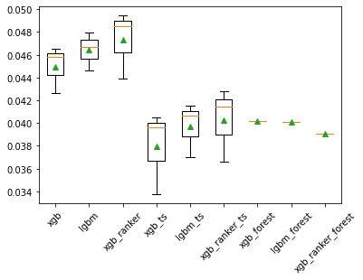

```python
plt.boxplot(res_cv_forest.values(), labels=res_cv_forest.keys(), showmeans=True, manage_ticks=True)
plt.xticks(rotation=45);plt.show()
```

### Diagnóstico

- Nenhum modelo superou o lgbm com group 3-fold (NR__Rio)
- XGB Ranker perfomou pior que os seus pares
- Modelos time series performaram melhor que o esperado
- Otimização bayesiana não funcionou como o esperado

```python
print("Menor é melhor:", min_cols)
leaderboard_forest = df_metrics_cons_forest[df_metrics_cons_forest.Categoria.isin(["Performance", "Risk", "MMC"])].loc[:,model_names_forest]
leaderboard_forest.astype(float).style.apply(visualize.highlight_max, axis = 1)
```

```
Menor é melhor: ['Feat_exp_max', 'Validation_SD', 'corr_with_example_preds']
```

| Metrica | ex_preds | xgb | lgbm | xgb_ranker | xgb_ts | lgbm_ts | xgb_ranker_ts | xgb_forest | lgbm_forest | xgb_ranker_forest |
| --- | --- | --- | --- | --- | --- | --- | --- | --- | --- | --- |
| Validation_Sharpe | 0.9588 | 0.9584 | 1.1423 | 0.8849 | 1.0440 | 0.9155 | 0.9355 | 1.0295 | 1.0453 | 0.7578 |
| Validation_Mean | 0.0289 | 0.0270 | 0.0299 | 0.0259 | 0.0275 | 0.0264 | 0.0267 | 0.0275 | 0.0265 | 0.0199 |
| Feat_neutral_mean | 0.0260 | 0.0213 | 0.0259 | 0.0211 | 0.0229 | 0.0215 | 0.0224 | 0.0232 | 0.0209 | 0.0139 |
| Validation_SD | 0.0301 | 0.0282 | 0.0262 | 0.0293 | 0.0263 | 0.0288 | 0.0286 | 0.0267 | 0.0253 | 0.0263 |
| Feat_exp_max | 0.2917 | 0.2877 | 0.2526 | 0.3139 | 0.2529 | 0.2709 | 0.3101 | 0.2686 | 0.2621 | 0.2292 |
| Max_Drawdown | -0.0775 | -0.0581 | -0.0511 | -0.0805 | -0.0576 | -0.0732 | -0.0722 | -0.0687 | -0.0640 | -0.0695 |
| corr_plus_mmc_sharpe | 0.9588 | 0.8469 | 1.2072 | 0.7693 | 1.0310 | 0.8102 | 0.8699 | 1.0467 | 0.9779 | 0.5465 |
| val_mmc_mean | 0.0000 | 0.0018 | 0.0055 | -0.0013 | 0.0024 | -0.0002 | -0.0005 | 0.0013 | 0.0019 | 0.0015 |
| corr_with_example_preds | 1.0000 | 0.8831 | 0.8791 | 0.9347 | 0.8849 | 0.9171 | 0.9391 | 0.9166 | 0.8615 | 0.6440 |

## Meta Modelo

- Nenhum dos modelos individualmente conseguiu superar o modelo NR__RIO
- Vamos combinar as predições de todos os modelos e criar segunda camada (L1)
- Essa técnica se chama Ensemble Stacking

### Conjunto de dados L1

- Carregamos os 15 modelos L0 (usaremos apenas os hiperparâmetros)
- Treinamos todos os 15 novamente usando o Group 3-fold
- As predições dos modelos gerará o novo dataset (15 colunas x 501k linhas)

```python
#get data
df_train_l1, l1_features = meta_model.get_stacked_data_light(meta_model="Sao_Paulo", local="local")
df_train_l1.head()
```

|  | feature_lr | feature_ridge | feature_omp | feature_xgb | feature_lgbm | feature_xgb_ranker | feature_lr_ts | feature_ridge_ts | feature_omp_ts | feature_xgb_ts | feature_lgbm_ts | feature_xgb_ranker_ts | feature_xgb_forest | feature_lgbm_forest | feature_xgb_ranker_forest | target_nomi | era | id | target_kazutsugi |
| --- | --- | --- | --- | --- | --- | --- | --- | --- | --- | --- | --- | --- | --- | --- | --- | --- | --- | --- | --- |
| 0 | 0.4958 | 0.4962 | 0.5015 | 0.4932 | 0.5000 | 0.4392 | 0.4958 | 0.4975 | 0.5026 | 0.4929 | 0.4947 | 0.4500 | 0.4953 | 0.5079 | 0.3916 | 0.50 | 1 | n000315175b67977 | 0.75 |
| 1 | 0.5142 | 0.5078 | 0.5089 | 0.4977 | 0.5034 | 0.5121 | 0.5142 | 0.5045 | 0.5083 | 0.4994 | 0.5011 | 0.5159 | 0.5010 | 0.5018 | 0.3573 | 0.25 | 1 | n0014af834a96cdd | 0.25 |
| 2 | 0.4935 | 0.4918 | 0.4947 | 0.4840 | 0.4929 | 0.4197 | 0.4935 | 0.4938 | 0.4983 | 0.4868 | 0.4883 | 0.3998 | 0.4943 | 0.4871 | 0.5372 | 0.25 | 1 | n001c93979ac41d4 | 0.00 |
| 3 | 0.5108 | 0.5043 | 0.5087 | 0.4967 | 0.5035 | 0.5377 | 0.5108 | 0.5019 | 0.5111 | 0.4977 | 0.5022 | 0.5379 | 0.4997 | 0.5082 | 0.7133 | 0.25 | 1 | n0034e4143f22a13 | 0.00 |
| 4 | 0.4925 | 0.4919 | 0.4899 | 0.4905 | 0.4721 | 0.3906 | 0.4925 | 0.4922 | 0.4916 | 0.4885 | 0.4845 | 0.3843 | 0.4861 | 0.4771 | 0.3044 | 0.75 | 1 | n00679d1a636062f | 0.75 |

### Modelo L1

- Podemos combinar as predições dando pesos para cada uma (Voting Regressor)
- Atribuir pesos é similar a treinar uma regressão linear

```python
from sklearn.linear_model import LinearRegression

lr_param_grid =  {
    'fit_intercept' : [False],
    'normalize' : [False],

}



#print(grp_type)
result = evaluation.evaluate_model(df_train_l1[l1_features],
                                   df_train_l1['target_nomi'],
                                   LinearRegression(), 'lr_meta',
                                   lr_param_grid,
                                   scorer,
                                   n_iter=1,
                                   cv_folds=cv_grp,
                                   pipeline=None)
print("lr Lv.0: Spearman=0.035")
print("XGB_Ranker_cv Lv.0 (best score): Spearman=0.0512")
```

```
==> Starting K-fold cross validation for lr_meta model, 501808 examples
Fitting 3 folds for each of 1 candidates, totalling 3 fits
```

```
[Parallel(n_jobs=-1)]: Using backend LokyBackend with 4 concurrent workers.
[Parallel(n_jobs=-1)]: Done   3 out of   3 | elapsed:    7.0s remaining:    0.0s
[Parallel(n_jobs=-1)]: Done   3 out of   3 | elapsed:    7.0s finished
```

```
==> Elapsed seconds: 7.711
Best lr_meta model: LinearRegression(fit_intercept=False)
Best lr_meta score (val): 0.0481
lr Lv.0: Spearman=0.035
XGB_Ranker_cv Lv.0 (best score): Spearman=0.0512
```

### Block k-fold

- Dividimos os dados em 6 blocos ordenados de 20 eras cada
- Testamos em 1 bloco de 20 eras e treinamos nas restantes
- Total de 6 iterações (com busca bayesiana)

[figure not shown]

*Fonte: https://towardsdatascience.com/cross-validation-explained-evaluating-estimator-performance-e51e5430ff85*

### Nested k-fold

- Loops aninhados, mais robustos a overfitting
- Geramos um novo conjunto de dados

[figure not shown]

*Fonte: RASCHKA, S. “MLxtend: Providing machine learning and data science utilities and extensions to Python’s scientific computing”, The Journal of Open Source Software, v.3, n.24, abr.2018.*

### Modelos lineares L1 com autoML

- Se podemos fazer com regressção linear, podemos com todos os outros

```python
#%%time
#blist = ['ransac', 'tr', 'huber', 'svm']
wlist = ['ridge', 'lasso', 'en', 'lr','lar', 'llar', 'omp', 'br', 'ard', 'par', 'knn']
best_model, leaderboard  = \
                compare_models(fold=3,
                               sort='MSE',
                               #blacklist=blist,
                               whitelist=wlist,
                               turbo=True)
#leaderboard.to_excel("../../reports/pycaret_compare_results_meta_Sao_Paulo.xlsx",
#             sheet_name='Sheet_name_1', index=False)
#pd.read_excel("../../reports/pycaret_compare_results_meta_Sao_Paulo.xlsx", index=True)
```

|  | Model | MAE | MSE | RMSE | R2 | RMSLE | MAPE | TT (Sec) |
| --- | --- | --- | --- | --- | --- | --- | --- | --- |
| 0 | Ridge Regression | 0.1538 | 0.0499 | 0.2233 | 0.0023 | 0.1540 | 0.3148 | 0.1352 |
| 1 | Linear Regression | 0.1538 | 0.0499 | 0.2234 | 0.0023 | 0.1540 | 0.3149 | 0.1846 |
| 2 | Least Angle Regression | 0.1543 | 0.0499 | 0.2234 | 0.0016 | 0.1541 | 0.3159 | 0.1025 |
| 3 | Orthogonal Matching Pursuit | 0.1537 | 0.0499 | 0.2234 | 0.0022 | 0.1540 | 0.3146 | 0.0945 |
| 4 | Bayesian Ridge | 0.1538 | 0.0499 | 0.2233 | 0.0023 | 0.1540 | 0.3148 | 0.4076 |
| 5 | Automatic Relevance Determination | 0.1538 | 0.0499 | 0.2234 | 0.0023 | 0.1540 | 0.3148 | 0.6741 |
| 6 | Lasso Regression | 0.1501 | 0.0500 | 0.2236 | -0.0000 | 0.1542 | 0.3071 | 0.0881 |
| 7 | Elastic Net | 0.1501 | 0.0500 | 0.2236 | -0.0000 | 0.1542 | 0.3071 | 0.1017 |
| 8 | Lasso Least Angle Regression | 0.1501 | 0.0500 | 0.2236 | -0.0000 | 0.1542 | 0.3071 | 0.1033 |
| 9 | K Neighbors Regressor | 0.1869 | 0.0592 | 0.2433 | -0.1839 | 0.1669 | 0.3844 | 1.4656 |
| 10 | Passive Aggressive Regressor | 0.2109 | 0.0699 | 0.2618 | -0.3981 | 0.1810 | 0.4227 | 0.5322 |

### Ridge é um bom modelo L1

```python
coef_df = pd.DataFrame(models_meta_l1['ridge_l1'].model.coef_, index=l1_features,columns=["ridge_coef"])
coef_df['lf_coef'] = result[0].model.coef_ #precisa rodar a lr la em cima
coef_df.sort_values('ridge_coef', ascending=False).astype(float).style.apply(visualize.highlight_top3, axis=0)
```

|  | ridge_coef | lf_coef |
| --- | --- | --- |
| feature_xgb_forest | 0.1729 | 0.3240 |
| feature_lgbm | 0.1222 | 0.1984 |
| feature_lgbm_forest | 0.1113 | 0.1445 |
| feature_xgb_ts | 0.0857 | 0.2364 |
| feature_xgb | 0.0614 | -0.0614 |
| feature_lgbm_ts | 0.0574 | -0.0531 |
| feature_omp | 0.0488 | 0.3369 |
| feature_omp_ts | 0.0262 | -0.0754 |
| feature_lr_ts | 0.0258 | 0.0308 |
| feature_lr | 0.0258 | 0.0308 |
| feature_xgb_ranker_ts | 0.0146 | 0.0159 |
| feature_xgb_ranker | 0.0145 | -0.0082 |
| feature_xgb_ranker_forest | 0.0025 | -0.0007 |
| feature_ridge | -0.0048 | -0.5143 |
| feature_ridge_ts | -0.0453 | 0.3952 |

### Avaliando as predições nas eras 1-120

- Criamos 5 modelos L1: Group k-kold (3), Block k-fold (1), Nested k-fold (1)

```python
%%time
import warnings
warnings.filterwarnings('ignore')
from joblib import dump, load


models_meta_l1, preds_meta, feat_corrs_meta = dict(), dict(), dict()
era_scores_meta, df_metrics_meta, res_cv_meta=dict(), dict(), dict()


#load preds l1 (val)
path = '../../Data/processed/meta_model/Sao_Paulo/'
df_validation_l1 = pd.read_csv(path+'preds_l1_validation.csv')
l1_features = [c for c in df_validation_l1 if c.startswith("feature")]


file_path = '../../models/sao_paulo/'
nr_models = ['ex_preds', 'NR_Rio']
l1_models = ['ridge_l1', 'lgbm_l1', 'xgb_ts_l1', 'lgbm_forest_l1', 'xgb_loop_l1']
model_names_l1 = nr_models + l1_models


target = 'target_kazutsugi'
print("target name (kaz): ", target)
for model in model_names_l1[2:]:

    #load model complete pipe
    print("creating predictions to:", model)
    models_meta_l1[model] = load(file_path + model + '-cv.pkl')


    if model in ['xgb_loop_l1', 'lgbm_forest_l1']:
        res_cv_meta[model] = models_meta_l1[model].results

    else:
        res_cv_meta[model] = evaluation.get_cv_scores(models_meta_l1[model])


    #predicoes val1 & val2
    if model=='xgb_loop_l1':
        preds_meta[model] = \
        models_meta_l1[model].model.predict(df_validation_l1[l1_features].to_numpy())

    else:
        preds_meta[model] = models_meta_l1[model].model.predict(df_validation_l1[l1_features])


    #print("calculating metrics to:", model)
    #salvando as metricas
    era_scores_meta[model], df_metrics_meta[model], feat_corrs_meta[model], ex_preds = \
                    metrics.submission_metrics(df_validation, preds_meta[model], model, mmc=True)



##add NR_Rio
preds_meta['NR_Rio'] = df_validation_l1['feature_lgbm'].values
#print("calculating metrics to:", "NR_Rio")
era_scores_meta['NR_Rio'], df_metrics_meta['NR_Rio'], feat_corrs_meta['NR_Rio'], ex_preds = \
                    metrics.submission_metrics(df_validation, preds_meta['NR_Rio'], 'NR_Rio', mmc=True)


##add ex_preds
preds_meta['ex_preds'] = np.array(ex_preds)
#print("calculating metrics to:", 'ex_preds')
era_scores_meta[model], df_metrics_meta['ex_preds'], feat_corrs_meta['ex_preds'], ex_preds = \
                    metrics.submission_metrics(df_validation, preds_meta['ex_preds'], 'ex_preds', mmc=False)


#dict to dataframe
df_res_cv_meta = pd.DataFrame.from_dict(res_cv_meta)
df_preds_meta = pd.DataFrame.from_dict(preds_meta)
df_era_scores_meta = pd.DataFrame.from_dict(era_scores_meta)
df_feat_corrs_meta = pd.DataFrame.from_dict(feat_corrs_meta)
df_metrics_cons_meta = metrics.metrics_consolidated(df_metrics_meta)
```

```
target name (kaz):  target_kazutsugi
creating predictions to: ridge_l1
creating predictions to: lgbm_l1
creating predictions to: xgb_ts_l1
creating predictions to: lgbm_forest_l1
creating predictions to: xgb_loop_l1
CPU times: user 3min 57s, sys: 28.4 s, total: 4min 26s
Wall time: 4min 19s
```

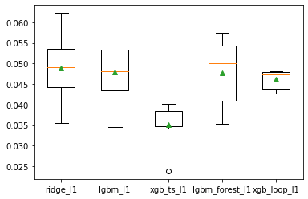

```python
plt.boxplot(res_cv_meta.values(), labels=res_cv_meta.keys(), showmeans=True, manage_ticks=True)
plt.xticks(rotation=0);plt.show()
```

### Diagnóstico

```python
print("Menor é melhor:", min_cols)
leaderboard_meta = df_metrics_cons_meta[df_metrics_cons_meta.Categoria.isin(["Performance", "Risk", "MMC"])].loc[:,l1_models]
leaderboard_meta.astype(float).style.apply(visualize.highlight_max, axis = 1)
```

```
Menor é melhor: ['Feat_exp_max', 'Validation_SD', 'corr_with_example_preds']
```

| Metrica | ridge_l1 | lgbm_l1 | xgb_ts_l1 | lgbm_forest_l1 | xgb_loop_l1 |
| --- | --- | --- | --- | --- | --- |
| Validation_Sharpe | 1.0014 | 0.9916 | 0.8789 | 0.9525 | 0.9582 |
| Validation_Mean | 0.0283 | 0.0281 | 0.0236 | 0.0279 | 0.0263 |
| Feat_neutral_mean | 0.0249 | 0.0234 | 0.0154 | 0.0223 | 0.0224 |
| Validation_SD | 0.0283 | 0.0283 | 0.0268 | 0.0292 | 0.0275 |
| Feat_exp_max | 0.2928 | 0.2855 | 0.2475 | 0.2841 | 0.2736 |
| Max_Drawdown | -0.0727 | -0.0732 | -0.0705 | -0.0753 | -0.0718 |
| corr_plus_mmc_sharpe | 1.0005 | 0.9883 | 0.7589 | 0.9063 | 0.9110 |
| val_mmc_mean | 0.0015 | 0.0015 | 0.0001 | 0.0018 | -0.0000 |
| corr_with_example_preds | 0.9379 | 0.9289 | 0.8130 | 0.9135 | 0.9122 |

### O modelo Ridge_l1 é o NR__São_Paulo

[figure not shown]

### Comparativo Modelos NR

```python
path = '../../Data/processed/predicoes_validacao/'
models_nr = ['ex_preds', 'NR_Rio', 'NR_Sao_Paulo']


from src.validation import metrics
from src.validation import metrics_description

preds_nr, feat_corrs_nr = dict(), dict()
era_scores_nr, df_metrics_nr = dict(), dict()

for model in models_nr[1:]:

    #predicoes val1 & val2
    print("creating predictions to:", model)
    preds_nr[model] =  pd.read_csv(path+model+'_preds_test.csv', index_col='id').values.reshape(1,-1)[0]

    #salvando as metricas
    era_scores_nr[model], df_metrics_nr[model], feat_corrs_nr[model], ex_preds = \
                        metrics.submission_metrics(df_validation, preds_nr[model], model, True)



#add ex_preds
print("creating predictions to: ex_preds")
preds_nr['ex_preds'] = np.array(ex_preds)
era_scores_nr['ex_preds'], df_metrics_nr['ex_preds'], feat_corrs_nr['ex_preds'], ex_preds = \
                        metrics.submission_metrics(df_validation, preds_nr['ex_preds'], "ex_preds", False)



#dict to dataframe
df_preds_nr = pd.DataFrame.from_dict(preds_nr)
df_era_scores_nr = pd.DataFrame.from_dict(era_scores_nr)
df_feat_corrs_nr = pd.DataFrame.from_dict(feat_corrs_nr)
df_metrics_cons_nr = metrics.metrics_consolidated(df_metrics_nr)
```

```
creating predictions to: NR_Rio
creating predictions to: NR_Sao_Paulo
creating predictions to: ex_preds
```

```python
print("Menor é melhor:", min_cols)
leaderboard_nr = df_metrics_cons_nr[df_metrics_cons_nr.Categoria.isin(["Performance", "Risk", "MMC"])].loc[:,models_nr]
leaderboard_nr.astype(float).style.apply(visualize.highlight_max, axis = 1)
```

```
Menor é melhor: ['Feat_exp_max', 'Validation_SD', 'corr_with_example_preds']
```

| Metrica | ex_preds | NR_Rio | NR_Sao_Paulo |
| --- | --- | --- | --- |
| Validation_Sharpe | 0.9588 | 1.1423 | 1.0014 |
| Validation_Mean | 0.0289 | 0.0299 | 0.0283 |
| Feat_neutral_mean | 0.0260 | 0.0259 | 0.0249 |
| Validation_SD | 0.0301 | 0.0262 | 0.0283 |
| Feat_exp_max | 0.2917 | 0.2526 | 0.2928 |
| Max_Drawdown | -0.0775 | -0.0511 | -0.0727 |
| corr_plus_mmc_sharpe | 0.9588 | 1.2072 | 1.0005 |
| val_mmc_mean | 0.0000 | 0.0055 | 0.0015 |
| corr_with_example_preds | 1.0000 | 0.8791 | 0.9379 |

### Relatório Final NR_Sao_Paulo

```python
%%time
from joblib import dump, load
file_path = '../../models/sao_paulo/'

models_120, preds_120, feat_corrs_120 = dict(), dict(), dict()
era_scores_120, df_metrics_120 = dict(), dict()
preds_val, feat_corrs_val, era_scores_val, df_metrics_val = dict(), dict(), dict(), dict()


model_cv = ['lr', 'ridge', 'omp', 'xgb', 'lgbm', 'xgb_ranker']
model_ts = ['lr_ts', 'ridge_ts', 'omp_ts', 'xgb_ts', 'lgbm_ts', 'xgb_ranker_ts']
model_forest = ['xgb_forest', "lgbm_forest", "xgb_ranker_forest"]
model_names_120 =  model_cv + model_ts + model_forest

#selected models to fit on image
model_cv = ['lr', 'omp', 'lgbm']
model_ts = ['xgb_ts', 'xgb_ranker_ts']
model_forest = ['xgb_forest', "lgbm_forest", "xgb_ranker_forest"]


model_names_selected =  model_cv + model_ts + model_forest
#model_names_120 = ['ex_preds', 'xgb_forest']#, 'xgb_ranker_forest']

target = 'target_kazutsugi'
print("target name (kaz): ", target)
for model in model_names_120:
    #load model complete pipe
    print("creating predictions to:", model)
    models_120[model] = load(file_path + model + '-cv.pkl')

    #predicoes 120 eras
    preds_120[model] = df_train_l1['feature_'+model]

    #salvando as metricas
    era_scores_120[model], df_metrics_120[model], feat_corrs_120[model], ex_preds = \
                        metrics.submission_metrics(df_train_l1, preds_120[model], model, False)

    #predicoes val1 & val2
    preds_val[model] = models_120[model].model.predict(df_validation[features])

    #salvando as metricas
    era_scores_val[model], df_metrics_val[model], feat_corrs_val[model], ex_preds = \
                        metrics.submission_metrics(df_validation, preds_val[model], model, False)



#dict to dataframe 120
df_preds_120 = pd.DataFrame.from_dict(preds_120)
df_era_scores_120 = pd.DataFrame.from_dict(era_scores_120)
df_feat_corrs_120 = pd.DataFrame.from_dict(feat_corrs_120)
df_metrics_cons_120 = metrics.metrics_consolidated(df_metrics_120)


#dict to dataframe val
df_preds_val = pd.DataFrame.from_dict(preds_val)
df_era_scores_val = pd.DataFrame.from_dict(era_scores_val)
df_feat_corrs_val = pd.DataFrame.from_dict(feat_corrs_val)
df_metrics_cons_val = metrics.metrics_consolidated(df_metrics_val)
```

```
target name (kaz):  target_kazutsugi
creating predictions to: lr
creating predictions to: ridge
creating predictions to: omp
creating predictions to: xgb
creating predictions to: lgbm
creating predictions to: xgb_ranker
creating predictions to: lr_ts
creating predictions to: ridge_ts
creating predictions to: omp_ts
creating predictions to: xgb_ts
creating predictions to: lgbm_ts
creating predictions to: xgb_ranker_ts
creating predictions to: xgb_forest
creating predictions to: lgbm_forest
creating predictions to: xgb_ranker_forest
CPU times: user 12min 14s, sys: 1min 32s, total: 13min 46s
Wall time: 13min 58s
```

### Formação de hipóteses e tomada de decisão

### Precisamos avaliar melhor as prediçoes nos dados de treino

```python
visualize.plot_era_scores(df_era_scores_120, model_names_120) #nao rodar de novo selected models
```

[interactive chart not shown]

### Processo de validação e teste

```python
cols = ['Validation_Mean']
visualize.leaderboard_test_val(df_metrics_cons_val, df_metrics_cons_120, model_names_120, cols)
```

|  | Validation_Mean | Validation_Mean_on_Test |
| --- | --- | --- |
| xgb_ranker | 0.0517 | 0.0259 |
| xgb_ranker_ts | 0.0515 | 0.0267 |
| lgbm_ts | 0.0501 | 0.0264 |
| xgb_ts | 0.0497 | 0.0275 |
| lgbm | 0.0491 | 0.0299 |
| xgb_forest | 0.0489 | 0.0275 |
| xgb | 0.0485 | 0.0270 |
| lgbm_forest | 0.0485 | 0.0265 |
| ridge | 0.0411 | 0.0172 |
| ridge_ts | 0.0404 | 0.0170 |
| omp | 0.0396 | 0.0180 |
| omp_ts | 0.0393 | 0.0173 |
| lr | 0.0379 | 0.0177 |
| lr_ts | 0.0379 | 0.0177 |
| xgb_ranker_forest | 0.0327 | 0.0199 |

### Mudando a métrica de interesse

```python
cols = ['Validation_Sharpe','Validation_Mean']
visualize.leaderboard_test_val(df_metrics_cons_val, df_metrics_cons_120, model_names_120, cols)
```

|  | Validation_Sharpe | Validation_Mean | Validation_Sharpe_on_Test | Validation_Mean_on_Test |
| --- | --- | --- | --- | --- |
| lgbm_forest | 1.7757 | 0.0485 | 1.0453 | 0.0265 |
| lgbm | 1.6764 | 0.0491 | 1.1423 | 0.0299 |
| xgb_ts | 1.5002 | 0.0497 | 1.0440 | 0.0275 |
| xgb_forest | 1.4929 | 0.0489 | 1.0295 | 0.0275 |
| lgbm_ts | 1.4810 | 0.0501 | 0.9155 | 0.0264 |
| xgb_ranker_ts | 1.4756 | 0.0515 | 0.9355 | 0.0267 |
| xgb_ranker | 1.4544 | 0.0517 | 0.8849 | 0.0259 |
| xgb | 1.4216 | 0.0485 | 0.9584 | 0.0270 |
| xgb_ranker_forest | 1.3931 | 0.0327 | 0.7578 | 0.0199 |
| omp | 1.1853 | 0.0396 | 0.5391 | 0.0180 |
| lr | 1.1838 | 0.0379 | 0.5411 | 0.0177 |
| lr_ts | 1.1838 | 0.0379 | 0.5411 | 0.0177 |
| omp_ts | 1.1696 | 0.0393 | 0.5075 | 0.0173 |
| ridge | 1.1481 | 0.0411 | 0.4846 | 0.0172 |
| ridge_ts | 1.1037 | 0.0404 | 0.4649 | 0.0170 |

### Diversidade dos modelos L0

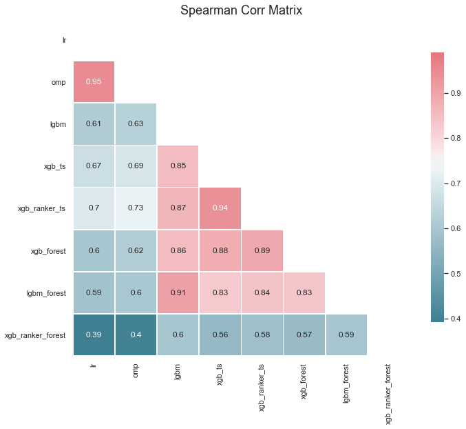

```python
visualize.plot_corr_matrix(df_preds_120) #nao rodar de novo selected models
```

## Para o próximo modelo

- Investigar a melhor métrica de interesse
- Implementar um esquema de validação mais robusto
- Garantir que a otimização de hiperparâmetros selecione o melhor modelo
- Aumentar a diversidade dos modelos L0